# **Advanced Machine Learning (GR5242) Final Project**

## **Zihan Zhou (zz2573), Qianyu Zhao (qz2345), Rener Zhang (rz2449)**

# Load Required Packages

```python
!pip install --upgrade tensorflow-gpu
!pip install --upgrade grpcio
```

```python
import os
import tensorflow as tf
import numpy as np
from tensorflow import keras
from tensorflow.keras import Sequential, layers
from PIL import Image
from matplotlib import pyplot as plt
import datetime
import time
import tensorboard

try:
  %tensorflow_version 2.x
except Exception:
  pass

# Load the TensorBoard notebook extension
%load_ext tensorboard
```

```
TensorFlow is already loaded. Please restart the runtime to change versions.
```

# Load in Data (MNIST-Fashion)

```python
fashion_mnist = keras.datasets.fashion_mnist

(train_images, train_labels), (test_images, test_labels) = fashion_mnist.load_data()

train_images = train_images.astype('float32')
test_images = test_images.astype('float32')

# Normalizing the images to the range of [0., 1.]
train_images /= 255.
test_images /= 255.

# Batching for stochastic optimization
TRAIN_BUF = 60000
BATCH_SIZE = 300
TEST_BUF = 10000

train_dataset = tf.data.Dataset.from_tensor_slices((train_images, train_labels)).shuffle(TRAIN_BUF).batch(BATCH_SIZE)
test_dataset = tf.data.Dataset.from_tensor_slices((test_images, test_labels)).shuffle(TRAIN_BUF).batch(BATCH_SIZE)
```

```
Downloading data from https://storage.googleapis.com/tensorflow/tf-keras-datasets/train-labels-idx1-ubyte.gz
Downloading data from https://storage.googleapis.com/tensorflow/tf-keras-datasets/train-images-idx3-ubyte.gz
Downloading data from https://storage.googleapis.com/tensorflow/tf-keras-datasets/t10k-labels-idx1-ubyte.gz
Downloading data from https://storage.googleapis.com/tensorflow/tf-keras-datasets/t10k-images-idx3-ubyte.gz
```

# Prior Visualization

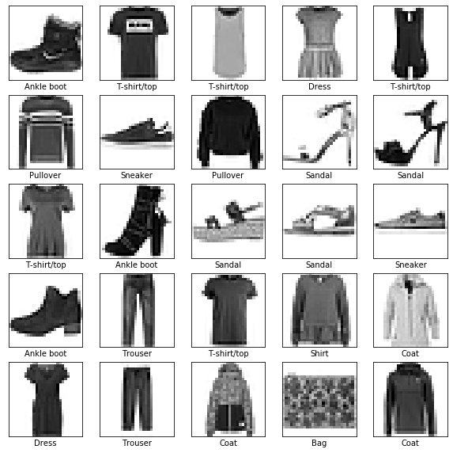

```python
class_names = ['T-shirt/top', 'Trouser', 'Pullover', 'Dress', 'Coat',
               'Sandal', 'Shirt', 'Sneaker', 'Bag', 'Ankle boot']
plt.figure(figsize=(10,10))
for i in range(25):
    plt.subplot(5,5,i+1)
    plt.xticks([])
    plt.yticks([])
    plt.grid(False)
    plt.imshow(train_images[i].reshape(28,28), cmap=plt.cm.binary)
    plt.xlabel(class_names[train_labels[i]])
plt.show()
```

# Normal VAE

## Define VAE Class

```python
class VAE(keras.Model):

    def __init__(self):
        super(VAE, self).__init__()

        self.layer1 = layers.Dense(128)
        self.layer2 = layers.Dense(z_dim)
        self.layer3 = layers.Dense(z_dim)

        self.layer4 = layers.Dense(128)
        self.layer5 = layers.Dense(784)

    def encoder(self, x):

        h = tf.nn.relu(self.layer1(x))

        mu = self.layer2(h)

        log_var = self.layer3(h)

        return mu, log_var

    def decoder(self, z):

        output = tf.nn.sigmoid(self.layer4(z))
        output = self.layer5(tf.nn.sigmoid(output))

        return output

    def reparameterize(self, mu, log_var):

        eps = tf.random.normal(log_var.shape)

        std = tf.math.exp(log_var)**0.5

        z = mu + std * eps
        return z

    def call(self, inputs, training=None):

        mu, log_var = self.encoder(inputs)

        z = self.reparameterize(mu, log_var)

        x_hat = self.decoder(z)

        return x_hat,mu,z,log_var
```

## Define an Auxiliary Function for Visualization

```python
def gen_image(x_hat, epoch, model='Normal'):
  fig = plt.figure(figsize=(4,4))
  for i in range(16):
      plt.subplot(4,4,i+1)
      plt.xticks([])
      plt.yticks([])
      plt.grid(False)
      plt.axis('off')
      plt.imshow(x_hat[i], cmap=plt.cm.binary)
  plt.savefig(model+str(epoch)+'.png')
  plt.show()

rdm_vector_for_generation = tf.random.normal([16,20], seed = 0)
```

## Model Training

```
Epoch:  1
######## Training time: 5.154770 s ########
```

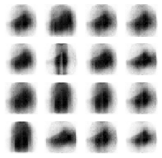

```
Epoch:  2
######## Training time: 5.281051 s ########
Epoch:  3
######## Training time: 5.728441 s ########
Epoch:  4
######## Training time: 4.906121 s ########
Epoch:  5
######## Training time: 4.923279 s ########
Epoch:  6
######## Training time: 6.218647 s ########
Epoch:  7
######## Training time: 5.203453 s ########
Epoch:  8
######## Training time: 5.042576 s ########
Epoch:  9
######## Training time: 5.661019 s ########
Epoch:  10
######## Training time: 5.340715 s ########
Epoch:  11
######## Training time: 5.232612 s ########
Epoch:  12
######## Training time: 5.859477 s ########
Epoch:  13
######## Training time: 6.459102 s ########
Epoch:  14
######## Training time: 5.100722 s ########
Epoch:  15
######## Training time: 5.213145 s ########
Epoch:  16
######## Training time: 5.793890 s ########
Epoch:  17
######## Training time: 5.244675 s ########
Epoch:  18
######## Training time: 5.409007 s ########
Epoch:  19
######## Training time: 6.391673 s ########
Epoch:  20
######## Training time: 5.304746 s ########
Epoch:  21
######## Training time: 5.337101 s ########
```

[output cut: 45 more lines]

```
######## Training time: 5.601556 s ########
Epoch:  45
######## Training time: 5.839153 s ########
Epoch:  46
######## Training time: 6.399658 s ########
Epoch:  47
######## Training time: 5.276218 s ########
Epoch:  48
######## Training time: 5.361681 s ########
Epoch:  49
######## Training time: 5.327852 s ########
Epoch:  50
######## Training time: 5.398601 s ########
Epoch:  51
######## Training time: 5.363213 s ########
```

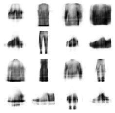

```
Epoch:  52
######## Training time: 5.391142 s ########
Epoch:  53
######## Training time: 5.368150 s ########
Epoch:  54
######## Training time: 5.425556 s ########
Epoch:  55
######## Training time: 5.482080 s ########
Epoch:  56
######## Training time: 5.480618 s ########
Epoch:  57
######## Training time: 5.421857 s ########
Epoch:  58
######## Training time: 5.451740 s ########
Epoch:  59
######## Training time: 5.532490 s ########
Epoch:  60
######## Training time: 5.506052 s ########
Epoch:  61
######## Training time: 5.496630 s ########
Epoch:  62
######## Training time: 5.451449 s ########
Epoch:  63
######## Training time: 5.497800 s ########
Epoch:  64
######## Training time: 5.520756 s ########
Epoch:  65
######## Training time: 5.589885 s ########
Epoch:  66
######## Training time: 5.587314 s ########
Epoch:  67
######## Training time: 5.697782 s ########
Epoch:  68
######## Training time: 6.317003 s ########
Epoch:  69
######## Training time: 5.963789 s ########
Epoch:  70
######## Training time: 5.695981 s ########
Epoch:  71
######## Training time: 5.624719 s ########
```

[output cut: 45 more lines]

```
######## Training time: 5.947342 s ########
Epoch:  95
######## Training time: 6.009107 s ########
Epoch:  96
######## Training time: 6.013201 s ########
Epoch:  97
######## Training time: 6.033584 s ########
Epoch:  98
######## Training time: 6.124492 s ########
Epoch:  99
######## Training time: 6.087989 s ########
Epoch:  100
######## Training time: 6.189110 s ########
Epoch:  101
######## Training time: 6.115164 s ########
```

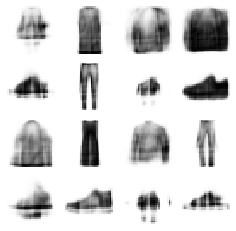

```
Epoch:  102
######## Training time: 6.153626 s ########
Epoch:  103
######## Training time: 6.200774 s ########
Epoch:  104
######## Training time: 6.334534 s ########
Epoch:  105
######## Training time: 6.295199 s ########
Epoch:  106
######## Training time: 6.242669 s ########
Epoch:  107
######## Training time: 6.297524 s ########
Epoch:  108
######## Training time: 6.328228 s ########
Epoch:  109
######## Training time: 6.349602 s ########
Epoch:  110
######## Training time: 6.296851 s ########
Epoch:  111
######## Training time: 6.348454 s ########
Epoch:  112
######## Training time: 6.432255 s ########
Epoch:  113
######## Training time: 6.334107 s ########
Epoch:  114
######## Training time: 6.271610 s ########
Epoch:  115
######## Training time: 6.360223 s ########
Epoch:  116
######## Training time: 6.368050 s ########
Epoch:  117
######## Training time: 6.404503 s ########
Epoch:  118
######## Training time: 6.342795 s ########
Epoch:  119
######## Training time: 7.073842 s ########
Epoch:  120
######## Training time: 6.850474 s ########
Epoch:  121
######## Training time: 6.434032 s ########
```

[output cut: 45 more lines]

```
######## Training time: 6.912955 s ########
Epoch:  145
######## Training time: 6.880476 s ########
Epoch:  146
######## Training time: 6.881562 s ########
Epoch:  147
######## Training time: 6.863611 s ########
Epoch:  148
######## Training time: 6.907027 s ########
Epoch:  149
######## Training time: 6.988272 s ########
Epoch:  150
######## Training time: 6.882724 s ########
Epoch:  151
######## Training time: 6.986245 s ########
```

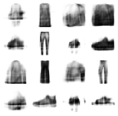

```
Epoch:  152
######## Training time: 6.948710 s ########
Epoch:  153
######## Training time: 7.169287 s ########
Epoch:  154
######## Training time: 7.156430 s ########
Epoch:  155
######## Training time: 7.237541 s ########
Epoch:  156
######## Training time: 7.307587 s ########
Epoch:  157
######## Training time: 7.317448 s ########
Epoch:  158
######## Training time: 7.276072 s ########
Epoch:  159
######## Training time: 7.032864 s ########
Epoch:  160
######## Training time: 7.081668 s ########
Epoch:  161
######## Training time: 7.119776 s ########
Epoch:  162
######## Training time: 7.214711 s ########
Epoch:  163
######## Training time: 7.229498 s ########
Epoch:  164
######## Training time: 7.781083 s ########
Epoch:  165
######## Training time: 7.668396 s ########
Epoch:  166
######## Training time: 7.225399 s ########
Epoch:  167
######## Training time: 7.089188 s ########
Epoch:  168
######## Training time: 7.190010 s ########
Epoch:  169
######## Training time: 7.369162 s ########
Epoch:  170
######## Training time: 7.307319 s ########
Epoch:  171
######## Training time: 7.238788 s ########
```

[output cut: 43 more lines]

```
######## Training time: 7.539195 s ########
Epoch:  194
######## Training time: 7.590512 s ########
Epoch:  195
######## Training time: 7.605475 s ########
Epoch:  196
######## Training time: 7.572592 s ########
Epoch:  197
######## Training time: 7.565747 s ########
Epoch:  198
######## Training time: 7.728742 s ########
Epoch:  199
######## Training time: 7.691270 s ########
Epoch:  200
######## Training time: 7.609711 s ########
```

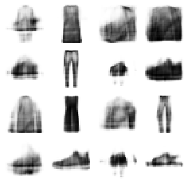

```python
!rm -rf ./logs/

lr = 1e-3
z_dim = 20
epochs = 200

model_N = VAE()
model_N.build(input_shape=(4, 784))
optimizer = tf.optimizers.Adam(lr)

z_label = tf.zeros([300],dtype=tf.uint8)
z_val = tf.zeros([300,z_dim],dtype= tf.float32)

N_elbo = keras.metrics.Mean('Normal ELBO', dtype=tf.float32)
current_time = datetime.datetime.now().strftime("%Y%m%d-%H%M%S")
log_dir = 'logs/' + current_time
summary_writer = tf.summary.create_file_writer(log_dir)

for epoch in range(1, epochs+1):
    start_time = time.time()
    for x_train, y_train in train_dataset:

        x_train = tf.reshape(x_train, [-1, 784])

        with tf.GradientTape() as tape:
            x_rec_logits,mu,z,log_var = model_N(x_train)
            z_label = tf.concat([z_label,y_train],0)
            z_val = tf.concat([z_val,z],0)
            rec_loss = tf.nn.sigmoid_cross_entropy_with_logits(labels=x_train, logits=x_rec_logits)
            rec_loss = tf.reduce_sum(rec_loss) / x_train.shape[0]

            kl_div = -0.5 * (log_var + 1 - mu**2 - tf.exp(log_var))
            kl_div = tf.reduce_sum(kl_div) / x_train.shape[0]

            loss = rec_loss + 1. * kl_div

        grads = tape.gradient(loss, model_N.trainable_variables)
        optimizer.apply_gradients(zip(grads, model_N.trainable_variables))
        N_elbo(-loss)

        with summary_writer.as_default():
          tf.summary.scalar('Normal ELBO', N_elbo.result(), step=epoch)


    end_time = time.time()
    print('Epoch: ', epoch)
    print('######## Training time: %f' % (end_time-start_time), 's ########')
    if epoch % 50 == 1 or epoch == 200:
      logits = model_N.decoder(rdm_vector_for_generation)
      x_hat = tf.sigmoid(logits)
      x_hat = tf.reshape(x_hat, [-1, 28, 28]).numpy() *255.
      gen_image(x_hat, epoch, 'Normal')
```

```python
%tensorboard --logdir logs/
```

```
Reusing TensorBoard on port 6006 (pid 868), started 1:35:16 ago. (Use '!kill 868' to kill it.)
```

# Continuous Bernoulli VAE

## Auxiliary Functions for CB

```python
def CB_log_norm(lam, approx = 0.01):
  lam = tf.clip_by_value(lam, 1e-06, 1.0-(1e-06))
  # if |lam-0.5| < approx, use taylor approximation to avoid numeric instability
  log_norm = tf.math.log(1e-6 + 2.0*tf.math.atanh(1.0-2.0*lam)/(1.0-2.0*lam))
  taylor_approx = tf.math.log(2.0) + 4/3*tf.pow(lam-0.5, 2) + 104/45*tf.pow(lam-0.5,4) + (64/7-64/15+64/81)*tf.pow(lam-0.5,6)
  return tf.where(tf.math.abs(lam-0.5)>=approx, log_norm, taylor_approx)

def CB_mean(lam, approx = 0.01):
  # if |lam-0.5| < approx, use taylor approximation to avoid numeric instability
  mean =  lam/(2.0*lam-1.0) + 1.0/(2.0*tf.math.atanh(1.0-2.0*lam))
  taylor_approx =  0.5 + 1/3*(lam-0.5) + 16/45*tf.pow(lam-0.5,3) + 704/945*tf.pow(lam-0.5,5)
  return tf.where(tf.math.abs(lam-0.5)>=approx, mean, taylor_approx)
```

## Define CB-VAE Class

```python
class CB_VAE(keras.Model):
  def __init__(self, latent_dim=20, n_hid=500, dropout_rate=0.1):
    super(CB_VAE, self).__init__()
    self.latent_dim = latent_dim
    self.n_hid = n_hid
    self.dropout_rate = dropout_rate

    # encoder NN
    self.inference = keras.Sequential(
        [ keras.layers.Conv2D(filters=32, kernel_size=(3,3), padding='same',
                              input_shape=(28,28,1), activation='relu'),
          keras.layers.MaxPool2D(),
          keras.layers.Flatten(),
          keras.layers.Dense(n_hid, activation='relu'),
          keras.layers.Dropout(dropout_rate),
          keras.layers.Dense(n_hid, activation='relu'),
          keras.layers.Dropout(dropout_rate),
          keras.layers.Dense(2*latent_dim)
        ]
    )

    # decoder NN
    self.generative = keras.Sequential(
        [
          keras.layers.InputLayer(input_shape=(latent_dim,)),
          keras.layers.Dense(n_hid, activation='relu'),
          keras.layers.Dropout(dropout_rate),
          keras.layers.Dense(n_hid, activation='relu'),
          keras.layers.Dropout(dropout_rate),
          keras.layers.Dense(784, activation='sigmoid')
        ]
    )

  @tf.function
  def sample(self, z, source = 'lambda'):
    lams = self.decode(z)
    if source == 'lambda':
      samples = lams

    elif source == 'mean':
      samples = CB_mean(lams)

    elif source == 'CB':
      """
      Random sample from CB using inverse transform
      """
      u = tf.random.uniform(shape=[784], minval=0, maxval=1, dtype='float32')
      samples = tf.where(tf.math.abs(lams-0.5)<approx, u,
                        (tf.math.log(u*(2.0*lams-1)+1.0-lams)-tf.math.log(1.0-lams)) / ((tf.math.log(lams)-tf.math.log(1.0-lams))))

    if len(z.shape) == 2:
        samples = tf.reshape(samples, (z.shape[0],28,28))
    else:
        samples = tf.reshape(samples, (28,28))
    return samples

  def encode(self, x):
    gaussian_params = self.inference(x)
    mean = gaussian_params[:,:self.latent_dim]
    #mean = tf.math.reduce_mean(mean, 0)
    sd = tf.math.softplus(gaussian_params[:,self.latent_dim:])
    #sd = tf.math.reduce_mean(sd, 0)
    return mean, sd

  def reparameterize(self, mean, sd):
    eps = tf.random.normal(mean.shape)
    return eps * sd + mean

  def decode(self, z):
    lam = self.generative(z)
    return lam
```

## Model Training

```
Epoch:  1
######## Training time: 18.221087 s ########
```

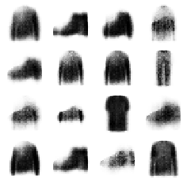

```
Epoch:  2
######## Training time: 16.408356 s ########
Epoch:  3
######## Training time: 16.243573 s ########
Epoch:  4
######## Training time: 15.916936 s ########
Epoch:  5
######## Training time: 16.166782 s ########
Epoch:  6
######## Training time: 16.338756 s ########
Epoch:  7
######## Training time: 16.546873 s ########
Epoch:  8
######## Training time: 16.049609 s ########
Epoch:  9
######## Training time: 15.999264 s ########
Epoch:  10
######## Training time: 15.745936 s ########
Epoch:  11
######## Training time: 15.816549 s ########
Epoch:  12
######## Training time: 15.714397 s ########
Epoch:  13
######## Training time: 15.364830 s ########
Epoch:  14
######## Training time: 15.234679 s ########
Epoch:  15
######## Training time: 15.472703 s ########
Epoch:  16
######## Training time: 15.396388 s ########
Epoch:  17
######## Training time: 16.866962 s ########
Epoch:  18
######## Training time: 15.456614 s ########
Epoch:  19
######## Training time: 15.480665 s ########
Epoch:  20
######## Training time: 15.435315 s ########
Epoch:  21
######## Training time: 15.291976 s ########
```

[output cut: 45 more lines]

```
######## Training time: 15.160708 s ########
Epoch:  45
######## Training time: 15.235386 s ########
Epoch:  46
######## Training time: 16.094693 s ########
Epoch:  47
######## Training time: 15.187472 s ########
Epoch:  48
######## Training time: 15.231997 s ########
Epoch:  49
######## Training time: 15.206594 s ########
Epoch:  50
######## Training time: 15.332648 s ########
Epoch:  51
######## Training time: 15.282881 s ########
```

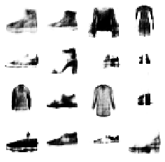

```
Epoch:  52
######## Training time: 15.668437 s ########
Epoch:  53
######## Training time: 15.386681 s ########
Epoch:  54
######## Training time: 15.690219 s ########
Epoch:  55
######## Training time: 15.577381 s ########
Epoch:  56
######## Training time: 15.526668 s ########
Epoch:  57
######## Training time: 15.895127 s ########
Epoch:  58
######## Training time: 16.581525 s ########
Epoch:  59
######## Training time: 15.621396 s ########
Epoch:  60
######## Training time: 15.692398 s ########
Epoch:  61
######## Training time: 15.258305 s ########
Epoch:  62
######## Training time: 14.969786 s ########
Epoch:  63
######## Training time: 15.316588 s ########
Epoch:  64
######## Training time: 15.259768 s ########
Epoch:  65
######## Training time: 15.263910 s ########
Epoch:  66
######## Training time: 15.984373 s ########
Epoch:  67
######## Training time: 15.053415 s ########
Epoch:  68
######## Training time: 15.108979 s ########
Epoch:  69
######## Training time: 15.313087 s ########
Epoch:  70
######## Training time: 15.396099 s ########
Epoch:  71
######## Training time: 15.488982 s ########
```

[output cut: 45 more lines]

```
######## Training time: 15.801856 s ########
Epoch:  95
######## Training time: 15.895643 s ########
Epoch:  96
######## Training time: 15.791530 s ########
Epoch:  97
######## Training time: 16.341543 s ########
Epoch:  98
######## Training time: 15.867966 s ########
Epoch:  99
######## Training time: 16.002064 s ########
Epoch:  100
######## Training time: 15.766327 s ########
Epoch:  101
######## Training time: 15.726646 s ########
```

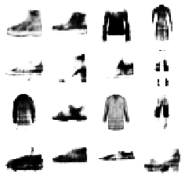

```
Epoch:  102
######## Training time: 15.812759 s ########
Epoch:  103
######## Training time: 15.692348 s ########
Epoch:  104
######## Training time: 15.605438 s ########
Epoch:  105
######## Training time: 16.657479 s ########
Epoch:  106
######## Training time: 15.537420 s ########
Epoch:  107
######## Training time: 15.710656 s ########
Epoch:  108
######## Training time: 15.213545 s ########
Epoch:  109
######## Training time: 15.312280 s ########
Epoch:  110
######## Training time: 15.151616 s ########
Epoch:  111
######## Training time: 15.154123 s ########
Epoch:  112
######## Training time: 15.283563 s ########
Epoch:  113
######## Training time: 15.463852 s ########
Epoch:  114
######## Training time: 15.374908 s ########
Epoch:  115
######## Training time: 15.442094 s ########
Epoch:  116
######## Training time: 15.107665 s ########
Epoch:  117
######## Training time: 16.360859 s ########
Epoch:  118
######## Training time: 15.295110 s ########
Epoch:  119
######## Training time: 15.260708 s ########
Epoch:  120
######## Training time: 15.258912 s ########
Epoch:  121
######## Training time: 15.454550 s ########
```

[output cut: 45 more lines]

```
######## Training time: 15.154856 s ########
Epoch:  145
######## Training time: 15.871696 s ########
Epoch:  146
######## Training time: 15.246736 s ########
Epoch:  147
######## Training time: 15.046648 s ########
Epoch:  148
######## Training time: 15.283546 s ########
Epoch:  149
######## Training time: 15.216842 s ########
Epoch:  150
######## Training time: 15.269538 s ########
Epoch:  151
######## Training time: 15.251140 s ########
```

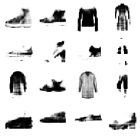

```
Epoch:  152
######## Training time: 15.318152 s ########
Epoch:  153
######## Training time: 15.172252 s ########
Epoch:  154
######## Training time: 15.126450 s ########
Epoch:  155
######## Training time: 15.257739 s ########
Epoch:  156
######## Training time: 15.117257 s ########
Epoch:  157
######## Training time: 15.012483 s ########
Epoch:  158
######## Training time: 16.690396 s ########
Epoch:  159
######## Training time: 15.186618 s ########
Epoch:  160
######## Training time: 15.250692 s ########
Epoch:  161
######## Training time: 15.188588 s ########
Epoch:  162
######## Training time: 15.131223 s ########
Epoch:  163
######## Training time: 15.039307 s ########
Epoch:  164
######## Training time: 15.182254 s ########
Epoch:  165
######## Training time: 15.998514 s ########
Epoch:  166
######## Training time: 15.213257 s ########
Epoch:  167
######## Training time: 15.137313 s ########
Epoch:  168
######## Training time: 15.213526 s ########
Epoch:  169
######## Training time: 15.127516 s ########
Epoch:  170
######## Training time: 15.248403 s ########
Epoch:  171
######## Training time: 15.214895 s ########
```

[output cut: 43 more lines]

```
######## Training time: 16.656256 s ########
Epoch:  194
######## Training time: 16.797622 s ########
Epoch:  195
######## Training time: 15.808285 s ########
Epoch:  196
######## Training time: 16.428730 s ########
Epoch:  197
######## Training time: 15.594529 s ########
Epoch:  198
######## Training time: 17.743330 s ########
Epoch:  199
######## Training time: 17.118923 s ########
Epoch:  200
######## Training time: 16.390299 s ########
```

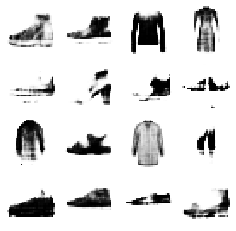

```python
!rm -rf ./logs/

train_elbo = keras.metrics.Mean('ELBO', dtype=tf.float32)
current_time = datetime.datetime.now().strftime("%Y%m%d-%H%M%S")
train_log_dir = 'logs/gradient_tape/' + current_time + '/train'
train_summary_writer = tf.summary.create_file_writer(train_log_dir)

model_CB = CB_VAE()
optimizer = keras.optimizers.Adam(0.001)

for epoch in range(1, epochs+1):
  start_time = time.time()
  for train_x,_ in train_dataset:
    x = tf.reshape(train_x, (-1,784))
    train_x = tf.reshape(train_x, (-1,28,28,1))

    # Training step
    with tf.GradientTape() as tape:
        mean, sd = model_CB.encode(train_x)
        z = model_CB.reparameterize(mean, sd)
        lams = model_CB.decode(z)
        lams = tf.clip_by_value(lams, 1e-06, 1.0 - (1e-06))

        log_norm_const = CB_log_norm(lams)
        log_p_all = tf.math.reduce_sum(x*tf.math.log(lams) + (1.0-x)*tf.math.log(1.0-lams) + log_norm_const, 1)
        log_p = tf.math.reduce_mean(log_p_all)

        KL = 0.5 * tf.math.reduce_sum(tf.pow(mean,2) + tf.pow(sd,2) - tf.math.log(tf.pow(sd,2))-1.0, 1)
        KL = tf.math.reduce_mean(KL)

        elbo = log_p - KL
        obj = -elbo # maximize ELBO -> minimize obj

    gradients = tape.gradient(obj, model_CB.trainable_variables)
    for i in range(len(gradients)):
      gradients[i] = tf.clip_by_value(gradients[i], -2, 2)
    optimizer.apply_gradients(zip(gradients, model_CB.trainable_variables))
    train_elbo(elbo)
    with train_summary_writer.as_default():
      tf.summary.scalar('ELBO', train_elbo.result(), step=epoch)

  end_time = time.time()
  print('Epoch: ', epoch)
  print('######## Training time: %f' % (end_time-start_time), 's ########')

  if epoch % 50 == 1 or epoch == 200:
    image = tf.reshape(model_CB.sample(rdm_vector_for_generation),(-1,28,28))
    gen_image(image, epoch, 'CB')
```

```python
%tensorboard --logdir logs/gradient_tape
```

# Comparison between the two models

## Randomly Generated Samples

[figure not shown]

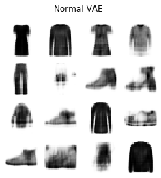

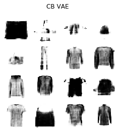

```python
def sample_plot(image, title):
  n = image.shape[0]
  fig = plt.figure(figsize=(np.sqrt(n), np.sqrt(n)))
  fig.suptitle(title)
  for i in range(n):
    plt.subplot(np.sqrt(n), np.sqrt(n), i+1)
    plt.yticks([])
    plt.grid(False)
    plt.axis('off')
    plt.imshow(tf.reshape(image[i,:], (28,28)), cmap=plt.cm.binary)
  plt.savefig(title+'.png')

sample_plot(train_images[0:16,:,:], title = 'Original Data')

z = tf.random.normal([16,20], seed = 0)
N_sample = model_N.decoder(z)
N_sample = tf.sigmoid(N_sample)
N_sample = tf.reshape(N_sample, [-1, 28, 28]).numpy() *255.
sample_plot(N_sample, title = 'Normal VAE')

CB_sample = model_CB.sample(z)
sample_plot(CB_sample, title = 'CB VAE')
```

We can see that both models are capable of generating artificial samples that are similar to the original ones. It seems that Normal VAE generate more blurry samples while samples generated by CB VAE are sharper.

## Reconstructed Samples

[figure not shown]

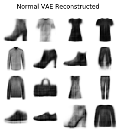

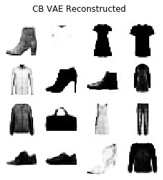

```python
np.random.seed(100)
images = train_images[np.random.randint(0, 60000, 16),:,:]

sample_plot(images, title = 'Data')

images.reshape(-1,784).shape
_,_,z_N,_ = model_N(images.reshape(-1,784))
tf.shape(z_N)
N_reconstruct = model_N.decoder(z_N)
N_reconstruct = tf.sigmoid(N_reconstruct)
N_reconstruct = tf.reshape(N_reconstruct, [-1, 28, 28]).numpy() *255.
sample_plot(N_reconstruct, title = 'Normal VAE Reconstructed')

z_CB = model_CB.encode(tf.reshape(images, (-1,28,28,1)))
tf.shape(z_CB)
CB_sample = model_CB.sample(z_CB[0])
sample_plot(CB_sample, title = 'CB VAE Reconstructed')
```

Both models reconstruct the original pictures accurately. The Normal VAE still reconstructed relatively blurry samples, while the CB VAE reconstructed samples with a high contrast ratio (i.e. pixel values are either close to 1 or 0).

# Classification Using Hidden Variables

Next we check the usefulness of our VAEs by doing classification using hidden variables. We compared three classifiers: logistic regression, simple CNN and multilayer CNN.

## Logistic Regression

```python
def logistc(train_x,train_y,test_x=None,test_y=None):
  logistic = keras.Sequential([
    keras.layers.Dense(10,activation='softmax')])
  logistic.compile(optimizer='adam',
              loss=tf.keras.losses.sparse_categorical_crossentropy,
              metrics=['accuracy'])
  logistic.fit(train_x,train_y,epochs=5, validation_data=(test_x,test_y), callbacks=[tensorboard_callback])
  test_loss, test_acc = logistic.evaluate(test_x,  test_y, verbose=2)
  print("Test Loss",test_loss,'\nTest accuracy:', test_acc)
```

### Using Original Data

```python
!rm -rf logs/logistic
```

```python
log_dir="logs/logistic/" + 'Original'
tensorboard_callback = tf.keras.callbacks.TensorBoard(log_dir=log_dir, histogram_freq=1)

start_time = time.time()
logistc(train_images.reshape(-1,784), train_labels, test_images.reshape(-1,784), test_labels)
end_time = time.time()
print('######## Training time: %f' % (end_time-start_time), 's ########')
```

```
Train on 60000 samples, validate on 10000 samples
10000/1 - 1s - loss: 0.4043 - accuracy: 0.8386
Test Loss 0.4575134253501892
Test accuracy: 0.8386
######## Training time: 31.419049 s ########
```

### Normal VAE

```python
log_dir="logs/logistic/" + 'Normal VAE'
tensorboard_callback = tf.keras.callbacks.TensorBoard(log_dir=log_dir, histogram_freq=1)

x_rec_logits,mu,z_N_large,log_var = model_N(train_images.reshape(-1,784))
z_label_large = tf.constant(train_labels)
x_rec_logits,mu,z_N_small,log_var = model_N(test_images.reshape(-1,784))
z_label_small = tf.constant(test_labels)

start_time = time.time()
logistc(z_N_large, z_label_large, z_N_small, z_label_small)
end_time = time.time()
print('######## Training time: %f' % (end_time-start_time), 's ########')
```

```
Train on 60000 samples, validate on 10000 samples
10000/1 - 1s - loss: 0.5861 - accuracy: 0.7459
Test Loss 0.7146141595840454
Test accuracy: 0.7459
######## Training time: 31.356496 s ########
```

### CB VAE

```python
mean1, sd1 = model_CB.encode(train_images[:40000,:,:].reshape(40000,28,28,1))
z_CB_large1 = model_CB.reparameterize(mean1, sd1)
mean2, sd2 = model_CB.encode(train_images[40000:,:,:].reshape(20000,28,28,1))
z_CB_large2 = model_CB.reparameterize(mean2, sd2)
mean3, sd3 = model_CB.encode(test_images.reshape(10000,28,28,1))
z_CB_small = model_CB.reparameterize(mean3, sd3)

z_CB_large = np.vstack((z_CB_large1.numpy(), z_CB_large2.numpy()))
z_CB_large = tf.constant(z_CB_large)
```

```python
log_dir="logs/logistic/" + 'CB VAE'
tensorboard_callback = tf.keras.callbacks.TensorBoard(log_dir=log_dir, histogram_freq=1)

start_time = time.time()
logistc(z_CB_large, z_label_large, z_CB_small, z_label_small)
end_time = time.time()
print('######## Training time: %f' % (end_time-start_time), 's ########')
```

```
Train on 60000 samples, validate on 10000 samples
10000/1 - 1s - loss: 0.5630 - accuracy: 0.7774
Test Loss 0.63462779545784
Test accuracy: 0.7774
######## Training time: 30.454013 s ########
```

```python
%tensorboard --logdir {'logs/logistic'}
```

We can see that both models have hidden variables that do not lose much of the information: the test accuracy only drops by less than 10% compared to using original data.

Next we train the logistic classifer on a small subset of data.

## Small Training Set Logistic

### Original Data

```python
log_dir="logs/logistic_small/" + 'Original'
tensorboard_callback = tf.keras.callbacks.TensorBoard(log_dir=log_dir, histogram_freq=1)

start_time = time.time()
logistc(test_images.reshape(-1,784), test_labels, train_images.reshape(-1,784), train_labels)
end_time = time.time()
print('######## Training time: %f' % (end_time-start_time), 's ########')
```

```
Train on 10000 samples, validate on 60000 samples
60000/1 - 4s - loss: 0.5054 - accuracy: 0.8251
Test Loss 0.5129957570274671
Test accuracy: 0.8251
######## Training time: 31.106559 s ########
```

### Normal VAE

```python
log_dir="logs/logistic_small/" + 'Normal VAE'
tensorboard_callback = tf.keras.callbacks.TensorBoard(log_dir=log_dir, histogram_freq=1)

start_time = time.time()
logistc(z_N_small, z_label_small, z_N_large, z_label_large)
end_time = time.time()
print('######## Training time: %f' % (end_time-start_time), 's ########')
```

```
Train on 10000 samples, validate on 60000 samples
60000/1 - 4s - loss: 1.1017 - accuracy: 0.7028
Test Loss 1.0442354736646016
Test accuracy: 0.70281667
######## Training time: 30.160944 s ########
```

### CB VAE

```python
log_dir="logs/logistic_small/" + 'CB VAE'
tensorboard_callback = tf.keras.callbacks.TensorBoard(log_dir=log_dir, histogram_freq=1)

start_time = time.time()
logistc(z_CB_small, z_label_small, z_CB_large, z_label_large)
end_time = time.time()
print('######## Training time: %f' % (end_time-start_time), 's ########')
```

```
Train on 10000 samples, validate on 60000 samples
60000/1 - 4s - loss: 0.9913 - accuracy: 0.7271
Test Loss 0.9590581136703491
Test accuracy: 0.72711664
######## Training time: 29.670434 s ########
```

```python
%tensorboard --logdir {'logs/logistic_small'}
```

The accuracy just drops slightly. Also note that it is more accurate to do classification on CB VAE's hidden variables.

## Simple CNN

```python
def simple_cnn_model(input_shape = (28,28,1)):
  model = tf.keras.Sequential()
  model.add(tf.keras.layers.Conv2D(32, kernel_size= (3, 3),padding="same",data_format="channels_last",input_shape = input_shape))
  model.add(tf.keras.layers.Flatten())
  model.add(tf.keras.layers.Dense(10, activation='softmax'))
  model.compile(optimizer="adam", loss='sparse_categorical_crossentropy', metrics=['accuracy'])
  return model

def simple_CNN(train_x,train_y,test_x=None,test_y=None,input_shape = (28,28,1)):
  cnn_net = simple_cnn_model(input_shape)
  cnn_net.fit(train_x,train_y,epochs=5, validation_data=(test_x,test_y), callbacks=[tensorboard_callback])
  test_loss, test_acc = cnn_net.evaluate(test_x,  test_y, verbose=2)
  print("Test Loss",test_loss,'\nTest accuracy:', test_acc)
```

### Original Data

#### Large Training Set

```python
log_dir="logs/SimpleCNN/" + 'Original'
tensorboard_callback = tf.keras.callbacks.TensorBoard(log_dir=log_dir, histogram_freq=1)

simple_CNN(train_images.reshape(60000,28,28,1), train_labels,
           test_images.reshape(10000,28,28,1), test_labels)
```

```
Train on 60000 samples, validate on 10000 samples
10000/1 - 1s - loss: 0.4396 - accuracy: 0.8364
Test Loss 0.47397767443656924
Test accuracy: 0.8364
```

#### Small Training Set

```python
log_dir="logs/SimpleCNN_small/" + 'Original'
tensorboard_callback = tf.keras.callbacks.TensorBoard(log_dir=log_dir, histogram_freq=1)

simple_CNN(test_images.reshape(10000,28,28,1), test_labels,
           train_images.reshape(60000,28,28,1), train_labels)
```

```
Train on 10000 samples, validate on 60000 samples
60000/1 - 4s - loss: 0.4701 - accuracy: 0.8269
Test Loss 0.509963079482317
Test accuracy: 0.8269333
```

### Normal VAE

#### Large Training Set

```python
log_dir="logs/SimpleCNN/" + 'Normal VAE'
tensorboard_callback = tf.keras.callbacks.TensorBoard(log_dir=log_dir, histogram_freq=1)

simple_CNN(tf.reshape(z_N_large,shape=[z_N_large.shape[0],10,-1,1]),
    z_label_large,
    tf.reshape(z_N_small,shape=[z_N_small.shape[0],10,-1,1]),
    z_label_small,input_shape = (10,2,1))
```

```
Train on 60000 samples, validate on 10000 samples
10000/1 - 1s - loss: 0.5217 - accuracy: 0.7484
Test Loss 0.6657297180652618
Test accuracy: 0.7484
```

#### Small Training Set

```python
log_dir="logs/SimpleCNN_small/" + 'Normal VAE'
tensorboard_callback = tf.keras.callbacks.TensorBoard(log_dir=log_dir, histogram_freq=1)

simple_CNN(tf.reshape(z_N_small,shape=[z_N_small.shape[0],10,-1,1]),
    z_label_small,
    tf.reshape(z_N_large,shape=[z_N_large.shape[0],10,-1,1]),
    z_label_large,input_shape = (10,2,1))
```

```
Train on 10000 samples, validate on 60000 samples
60000/1 - 4s - loss: 0.7063 - accuracy: 0.7523
Test Loss 0.6669752769470215
Test accuracy: 0.75231665
```

### CB VAE

#### Large Training Set

```python
log_dir="logs/SimpleCNN/" + 'CB VAE'
tensorboard_callback = tf.keras.callbacks.TensorBoard(log_dir=log_dir, histogram_freq=1)

simple_CNN(tf.reshape(z_CB_large,shape=[z_CB_large.shape[0],10,-1,1]),
    z_label_large,
    tf.reshape(z_CB_small,shape=[z_CB_small.shape[0],10,-1,1]),
    z_label_small,input_shape = (10,2,1))
```

```
Train on 60000 samples, validate on 10000 samples
10000/1 - 1s - loss: 0.5346 - accuracy: 0.7826
Test Loss 0.5998211010456085
Test accuracy: 0.7826
```

#### Small Training Set

```python
log_dir="logs/SimpleCNN_small/" + 'CB VAE'
tensorboard_callback = tf.keras.callbacks.TensorBoard(log_dir=log_dir, histogram_freq=1)

simple_CNN(tf.reshape(z_CB_small,shape=[z_CB_small.shape[0],10,-1,1]),
    z_label_small,
    tf.reshape(z_CB_large,shape=[z_CB_large.shape[0],10,-1,1]),
    z_label_large,input_shape = (10,2,1))
```

```
Train on 10000 samples, validate on 60000 samples
60000/1 - 4s - loss: 0.5783 - accuracy: 0.7805
Test Loss 0.5938787380536398
Test accuracy: 0.7805
```

```python
%tensorboard --logdir {"logs/SimpleCNN/"}
```

```python
%tensorboard --logdir {"logs/SimpleCNN_small/"}
```

## Multilayer CNN

```python
def cnn_model(input_shape = (28,28,1)):
  model = tf.keras.Sequential()
  model.add(tf.keras.layers.Conv2D(32, kernel_size= (3, 3),padding="same",data_format="channels_last",input_shape = input_shape))
  model.add(tf.keras.layers.MaxPooling2D((2, 2)))
  model.add(tf.keras.layers.Flatten())
  model.add(tf.keras.layers.Dense(128, activation='relu', kernel_initializer='he_uniform'))
  model.add(tf.keras.layers.Dense(10, activation='softmax'))
  model.compile(optimizer="adam", loss='sparse_categorical_crossentropy', metrics=['accuracy'])
  return model

def CNN(train_x,train_y,test_x=None,test_y=None,input_shape = (28,28,1)):
  cnn_net = cnn_model(input_shape)
  cnn_net.fit(train_x,train_y,epochs=5,validation_data=(test_x,test_y), callbacks=[tensorboard_callback])
  test_loss, test_acc = cnn_net.evaluate(test_x,  test_y, verbose=2)
  print("Test Loss",test_loss,'\nTest accuracy:', test_acc)
```

### Original Data

#### Large Training Set

```python
log_dir="logs/CNN/" + 'Original'
tensorboard_callback = tf.keras.callbacks.TensorBoard(log_dir=log_dir, histogram_freq=1)

CNN(train_images.reshape(60000,28,28,1), train_labels,
           test_images.reshape(10000,28,28,1), test_labels)
```

```
Train on 60000 samples, validate on 10000 samples
10000/1 - 1s - loss: 0.2106 - accuracy: 0.9071
Test Loss 0.2797308734714985
Test accuracy: 0.9071
```

#### Small Training Set

```python
log_dir="logs/CNN_small/" + 'Original'
tensorboard_callback = tf.keras.callbacks.TensorBoard(log_dir=log_dir, histogram_freq=1)

CNN(test_images.reshape(10000,28,28,1), test_labels,
           train_images.reshape(60000,28,28,1), train_labels)
```

```
Train on 10000 samples, validate on 60000 samples
60000/1 - 5s - loss: 0.3042 - accuracy: 0.8767
Test Loss 0.34805766528646154
Test accuracy: 0.8767
```

### Normal VAE

#### Large Training Set

```python
log_dir="logs/CNN/" + 'Normal VAE'
tensorboard_callback = tf.keras.callbacks.TensorBoard(log_dir=log_dir, histogram_freq=1)

CNN(tf.reshape(z_N_large,shape=[z_N_large.shape[0],10,-1,1]),
    z_label_large,
    tf.reshape(z_N_small,shape=[z_N_small.shape[0],10,-1,1]),
    z_label_small,input_shape = (10,2,1))
```

```
Train on 60000 samples, validate on 10000 samples
10000/1 - 1s - loss: 0.4395 - accuracy: 0.7914
Test Loss 0.5527063281536102
Test accuracy: 0.7914
```

#### Small Training Set

```python
log_dir="logs/CNN_small/" + 'Normal VAE'
tensorboard_callback = tf.keras.callbacks.TensorBoard(log_dir=log_dir, histogram_freq=1)

CNN(tf.reshape(z_N_small,shape=[z_N_small.shape[0],10,-1,1]),
    z_label_small,
    tf.reshape(z_N_large,shape=[z_N_large.shape[0],10,-1,1]),
    z_label_large,input_shape = (10,2,1))
```

```
Train on 10000 samples, validate on 60000 samples
60000/1 - 4s - loss: 0.6961 - accuracy: 0.7569
Test Loss 0.6473052744150162
Test accuracy: 0.7568833
```

### CB VAE

#### Large Training Set

```python
log_dir="logs/CNN/" + 'CB VAE'
tensorboard_callback = tf.keras.callbacks.TensorBoard(log_dir=log_dir, histogram_freq=1)

CNN(tf.reshape(z_CB_large,shape=[z_CB_large.shape[0],10,-1,1]),
    z_label_large,
    tf.reshape(z_CB_small,shape=[z_CB_small.shape[0],10,-1,1]),
    z_label_small,input_shape = (10,2,1))
```

```
Train on 60000 samples, validate on 10000 samples
10000/1 - 1s - loss: 0.5513 - accuracy: 0.8223
Test Loss 0.4842320017337799
Test accuracy: 0.8223
```

#### Small Training Set

```python
log_dir="logs/CNN_small/" + 'CB VAE'
tensorboard_callback = tf.keras.callbacks.TensorBoard(log_dir=log_dir, histogram_freq=1)

CNN(tf.reshape(z_CB_small,shape=[z_CB_small.shape[0],10,-1,1]),
    z_label_small,
    tf.reshape(z_CB_large,shape=[z_CB_large.shape[0],10,-1,1]),
    z_label_large,input_shape = (10,2,1))
```

```
Train on 10000 samples, validate on 60000 samples
60000/1 - 5s - loss: 0.5956 - accuracy: 0.7844
Test Loss 0.598391110364596
Test accuracy: 0.7844167
```

```python
%tensorboard --logdir {'logs/CNN'}
```

```python
%tensorboard --logdir {'logs/CNN_small'}
```